# Quantum walks Université Bordeaux

Dauliac julien

[figure not shown]

# Table of content 📖

- Classical Random walks and Markov chains
- Quantum walks

## Classical Random walks and Markov chains ⛓️

Markov chains are a mathematical tool describing probabilistic dynamic systems.

They play an important role in randomized algorithms

[figure not shown]

## Let's walk 🚶‍♂️

We will simulate a random walk to observe these properties

```python
import random # Our piece to choice walker direction

steps_number = 50    # Defines the total number of steps our walker will take
direction_probability = 0.5  # Defines the probability of our walker stepping to the right
initial_position = 0     # Defines the initial position of our walker
```

```python
def random_walk(direction_probability: float, steps_number: int, initial_position: int):
    position = initial_position
    # Repeatedly queries our random variable and moves our walker for the specified number of steps
    for j in range(steps_number):
        # Flips our coin
        coin_flip = np.random.choice(2, 1, p=[1-direction_probability, direction_probability])[0]
        position += 2*coin_flip-1 # Moves our walker according to the coin flip

    return position

walker_position = random_walk(direction_probability, steps_number, initial_position)
print("The walker is located at: x = {var}".format(var = walker_position))
```

```
The walker is located at: x = -8
```

### Distribution 📊

Let's display the distribution of our steps

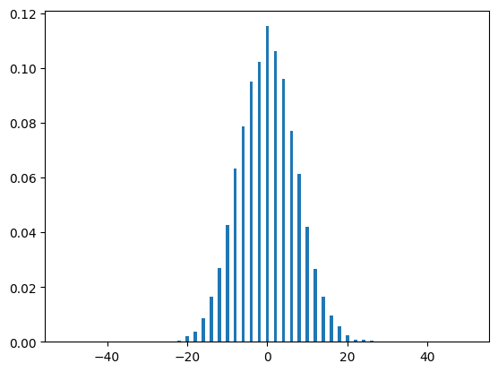

```python
dist(10000, steps_number, direction_probability, initial_position)
```

### Comparison with the theory 🆚

Our simulation look pretty binomial

We can now plot the distribution predicted in the math, and see if the two are the same...

### Comparison with the theory 🆚

```python
def binomial_height(position: int, steps_number: int, direction_probability: float):
    a = (steps_number + position)/2
    b = (steps_number - position)/2
    if (position%2 == 0):
        result = scipy.special.binom(steps_number, a)*(direction_probability**a)*((1-direction_probability)**b)
    else:
        result = 0
    return result
```

### Comparison with the theory 🆚

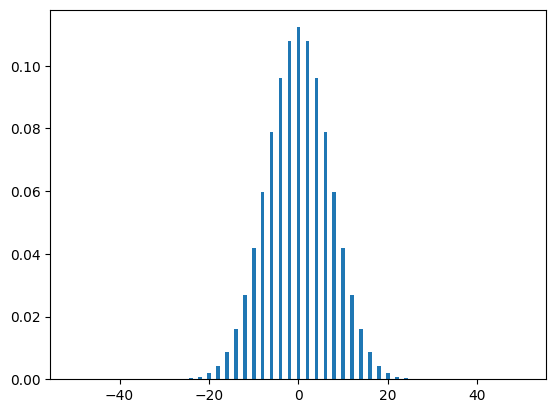

```python
positions = range(-1*steps_number, steps_number+1)
heights = [binomial_height(
    position,
    steps_number,
    direction_probability) for position in positions]
plt.bar(positions, heights)
plt.show()
```

## Quantum walks ⚛️

Quantum walks are random walks equivalent in quantum world.

[figure not shown]

## Quantum walks ⚛️

[figure not shown]

### Quantum walks applications

- Random walks discrete 📊
- Random walks continuous 📈
- Search algorithm 🔍
- Physical simulations 🔬
- Finance 💰

### Quantum walks complexity

Normal world: $$ O(\frac{1}{n}) $$

Quantum world: $$ O(\frac{1}{\sqrt{n}})$$

## Let's quantum walk ⚛️

[figure not shown]

## Let's quantum walk ⚛️

```python
# Qbits simulation
import cirq

number_qubits = 7
qubits = cirq.GridQubit.rect(1, number_qubits)

print(qubits)
```

```
[
    cirq.GridQubit(0, 0),
    cirq.GridQubit(0, 1),
    cirq.GridQubit(0, 2),
    cirq.GridQubit(0, 3),
    cirq.GridQubit(0, 4),
    cirq.GridQubit(0, 5),
    cirq.GridQubit(0, 6)
]
```

### Initialisation

```python
def initial_state():
    # Initalize🚶 position using the Pauli X gate.
    yield cirq.X.on(cirq.GridQubit(0, 1))
    # Initalize🪙 in |⬇️> state using the Pauli X gate.
    yield cirq.X.on(cirq.GridQubit(0, number_qubits))
```

### Our operators 👷‍♂️

[output not shown]

[figure not shown]

### Run our walker 🏃‍♂️

```python
number_qubits = 7
iterator = 30
sample_number = 5000


final = generate_walk(number_qubits, iterator, sample_number)
```

### Results

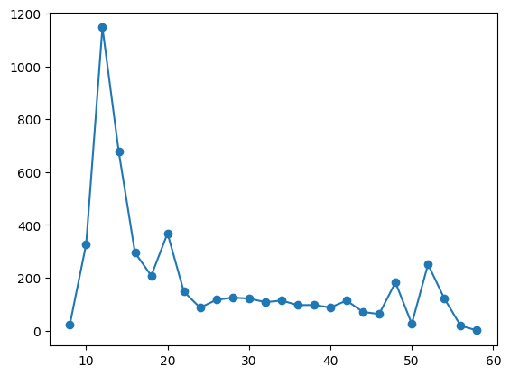

```python
graph(final)
```

### Results

If we invert 🪙 state:

### Results

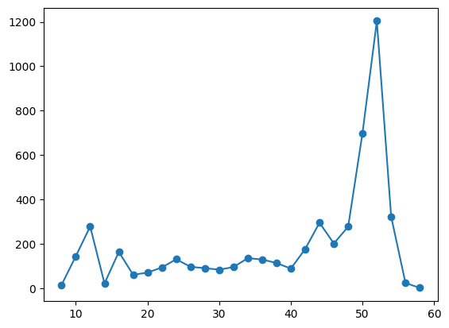

```python
# Override initial state
def initial_state():
    # Initalize🚶 position using the Pauli X gate.
    yield cirq.X.on(cirq.GridQubit(0, 1))
    # Keep 🪙 in |⬆️> state using the Pauli X gate.
    #yield cirq.X.on(cirq.GridQubit(0, number_qubits))

final = generate_walk(number_qubits, iterator, sample_number)
graph(final)
```

### Interferences 🔀

Depends on inital 🪙 state $\lvert\downarrow\rangle$ or $\lvert\uparrow\rangle$

[figure not shown]

### Without biaises ↕️

We will set our initial state to:

$$|i\rangle \ = \ \frac{|\uparrow\rangle \ + \ i|\downarrow\rangle}{\sqrt{2}}$$

This is implemented by applying a Hadamard gate to $|\uparrow\rangle$, and then applying an $S$ gate to the qubit.

### Without biaises ↕️

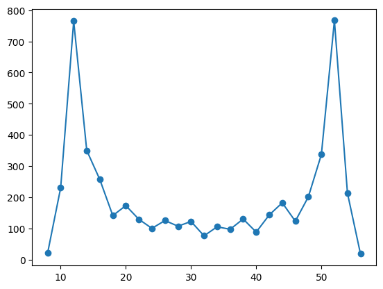

```python
def initial_state():
  # Initalize🚶 position using the Pauli X gate.
    yield cirq.X.on(cirq.GridQubit(0, 1))
    # Set 🪙 in |↕️> state.
    yield cirq.H.on(cirq.GridQubit(0, number_qubits)) # Hadamar gate
    yield cirq.S.on(cirq.GridQubit(0, number_qubits)) # S gate
# Re-compute results
final = generate_walk(number_qubits, iterator, sample_number)
graph(final)
```

### Cost and speed 💸

- $\sigma$ is the standard deviation
- $T$ is the number of time steps

In the case of a quantum walk $\sigma^2 \sim \ T^2$.

[figure not shown]

## References

[sources](https://github.com/Dauliac/Quantum-random-walks)

[forked from](https://quantumai.google/cirq/experiments/quantum_walks)

Filled with content of [this document](https://www.overleaf.com/read/gtdyjkykkprn)